# Homework3 Submission

Victor Aluko

2 March 2017

```
## Package 'sm', version 2.2-5.4: type help(sm) for summary information
```

## Exercise 1

### Plot the density distribution to compare the data set

Below is a density distribution plot of the klient1 and klient3 data set

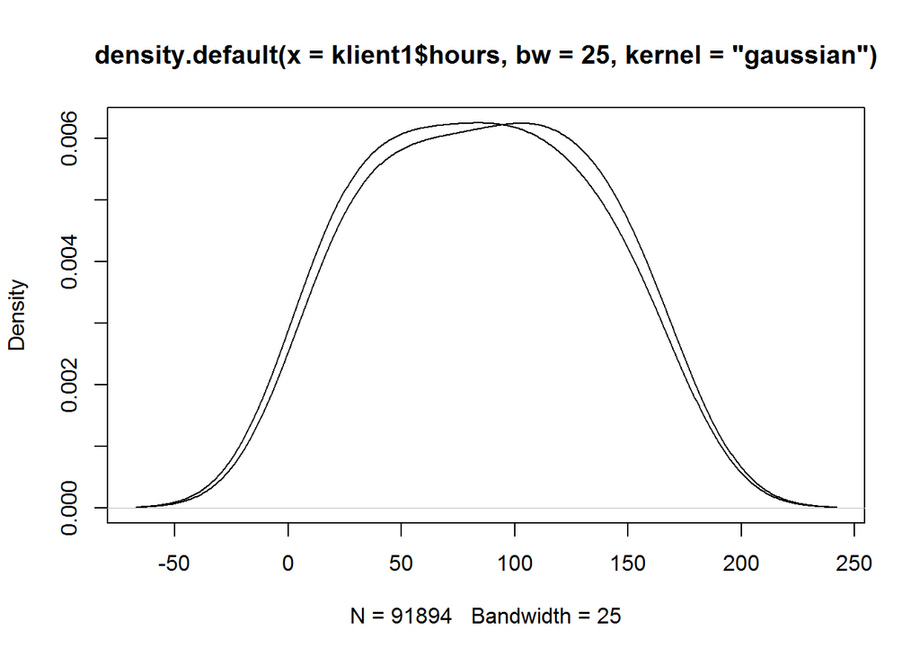

```r
klient1 = read.csv("klient1.txt", col.names = as.matrix("hours"))
klient3 = read.csv("klient3.txt", col.names = as.matrix("hours"))
plot(density(klient1$hours, kernel = "gaussian", bw=25))
lines(density(klient3$hours, kernel = "gaussian", bw=25))
```

### Characterise briefly these two data sets

At the bandwidth value, the curve shows that the data is nomally distributed. At lower bandwidth, the plot shows that the data has multiple modal points but these are then smoothed out

## Exercise 2

### Extract from above data information about Fridays and Saturday

```r
friday_klient1 = subset(klient1$hours, klient1$hours >= 96 & klient1$hours <= 120)
friday_klient3 = subset(klient3$hours, klient3$hours >= 96 & klient3$hours <= 120)
saturday_klient1 = subset(klient1$hours, klient1$hours >= 120 & klient1$hours <= 144)
saturday_klient3 = subset(klient3$hours, klient3$hours >= 120 & klient3$hours <= 144)
```

### Plot the four density plots (2 sets of clients, 2 days) as in task 1. by overlaying them above each other

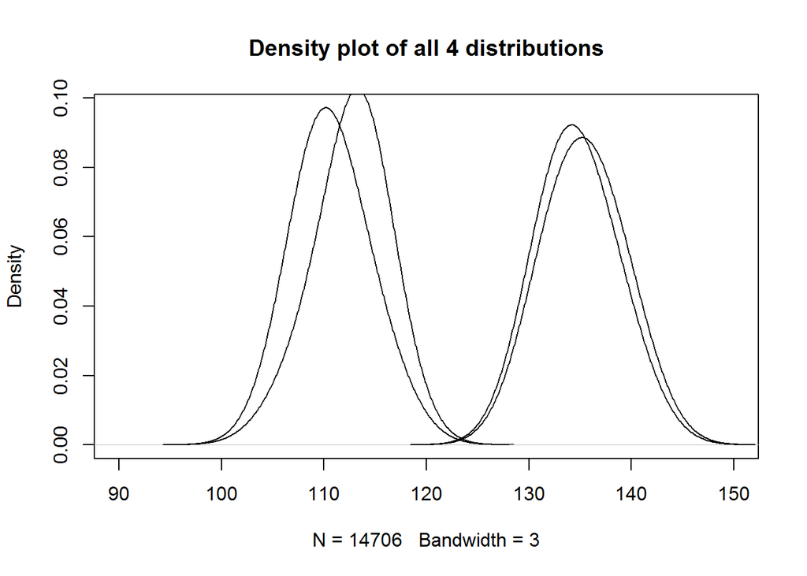

```r
plot(density(friday_klient1, kernel = "gaussian", bw=3), xlim=c(90,150),main = "Density plot of all 4 distributions")
lines(density(friday_klient3, kernel = "gaussian", bw=3))
lines(density(saturday_klient1, kernel = "gaussian", bw=3))
lines(density(saturday_klient3, kernel = "gaussian", bw=3))
```

### Select two different distributions (from four) and make a Q-Q plot to compare them

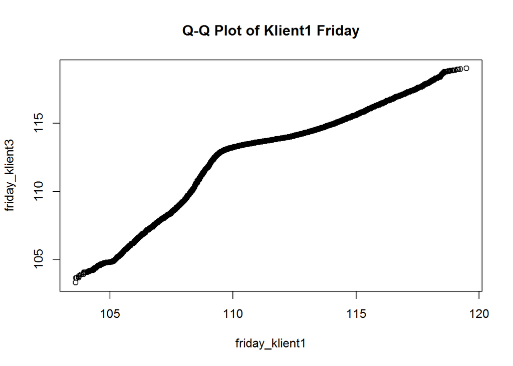

```r
qqplot(friday_klient1, friday_klient3, main = "Q-Q Plot of Klient1 Friday")
```

The graph shows that distribution of both data is not normally distributed. It is skewed more towards the friday_klient3. It is left skewed distribution. This indicates that the mean of the values of Klient3 Friday is less than the median value.

## Exercise 3

### Study the data product_time_shop.txt. Describe the data - what products, shops, how many purchases of different products in different shops, and which periods are covered?

First, reading the data

There are 5 shops in total.

```r
table(product_time_shop$shop_id)
```

```
##
##     3     4    18    21    32
## 31649 48811 24886 11090 22056
```

There are 11 products in total as shown below:

```r
table(product_time_shop$product)
```

```
##
##        Banana  Coffee_Cream        Eggs_1        Eggs_2        Grapes
##         24847         20531         10089           281          3202
##        Milk_1        Milk_2  Sour_Cream_1  Sour_Cream_2  Vastlakukkel
##         14874         25715          9704         15876          4109
## Whipped_Cream
##          9264
```

The purchases of the products for the different stores are given below:

```r
table(product_shop_sales$product[product_shop_sales$shop_id == 3])
```

```
##
##        Banana  Coffee_Cream        Eggs_1        Eggs_2        Grapes
##            12            12            11            11            12
##        Milk_1        Milk_2  Sour_Cream_1  Sour_Cream_2  Vastlakukkel
##            12            12            12            12             1
## Whipped_Cream
##            12
```

```r
table(product_shop_sales$product[product_shop_sales$shop_id == 4])
```

```
##
##        Banana  Coffee_Cream        Eggs_1        Eggs_2        Grapes
##            12            12            12            12            12
##        Milk_1        Milk_2  Sour_Cream_1  Sour_Cream_2  Vastlakukkel
##            12            12            12            12             1
## Whipped_Cream
##            12
```

```r
table(product_shop_sales$product[product_shop_sales$shop_id == 18])
```

```
##
##        Banana  Coffee_Cream        Eggs_1        Eggs_2        Grapes
##            12            12            11             0            12
##        Milk_1        Milk_2  Sour_Cream_1  Sour_Cream_2  Vastlakukkel
##            10            12            12            12             1
## Whipped_Cream
##            12
```

```r
table(product_shop_sales$product[product_shop_sales$shop_id == 21])
```

```
##
##        Banana  Coffee_Cream        Eggs_1        Eggs_2        Grapes
##            12            12             9             0            11
##        Milk_1        Milk_2  Sour_Cream_1  Sour_Cream_2  Vastlakukkel
##            11            12            12            12             1
## Whipped_Cream
##            12
```

```r
table(product_shop_sales$product[product_shop_sales$shop_id == 32])
```

```
##
##        Banana  Coffee_Cream        Eggs_1        Eggs_2        Grapes
##            12            12            11             0            12
##        Milk_1        Milk_2  Sour_Cream_1  Sour_Cream_2  Vastlakukkel
##            12            12            12            12             1
## Whipped_Cream
##            12
```

The periods covered for the entire data is:

```r
range(product_shop_sales$date[product_shop_sales$shop_id == 3])
```

```
## [1] 20140104 20141231
```

```r
range(product_shop_sales$date[product_shop_sales$shop_id == 4])
```

```
## [1] 20140104 20141231
```

```r
range(product_shop_sales$date[product_shop_sales$shop_id == 18])
```

```
## [1] 20140104 20141231
```

```r
range(product_shop_sales$date[product_shop_sales$shop_id == 21])
```

```
## [1] 20140104 20141231
```

```r
range(product_shop_sales$date[product_shop_sales$shop_id == 32])
```

```
## [1] 20140104 20141231
```

## Exercise 4

### Draw Violin Plots

The Violin Plot of the shop sales is given below

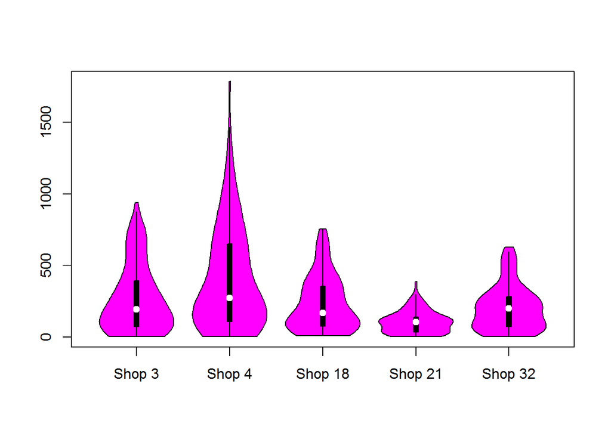

```r
shop_3_sales <- product_shop_sales$sales[product_shop_sales$shop_id == 3]
shop_4_sales <- product_shop_sales$sales[product_shop_sales$shop_id == 4]
shop_18_sales <- product_shop_sales$sales[product_shop_sales$shop_id == 18]
shop_21_sales <- product_shop_sales$sales[product_shop_sales$shop_id == 21]
shop_32_sales <- product_shop_sales$sales[product_shop_sales$shop_id == 32]
vioplot(shop_3_sales, shop_4_sales, shop_18_sales, shop_21_sales, shop_32_sales, names = c("Shop 3","Shop 4", "Shop 18", "Shop 21", "Shop 32"))
```

The violin Plot of the products with sales is given below

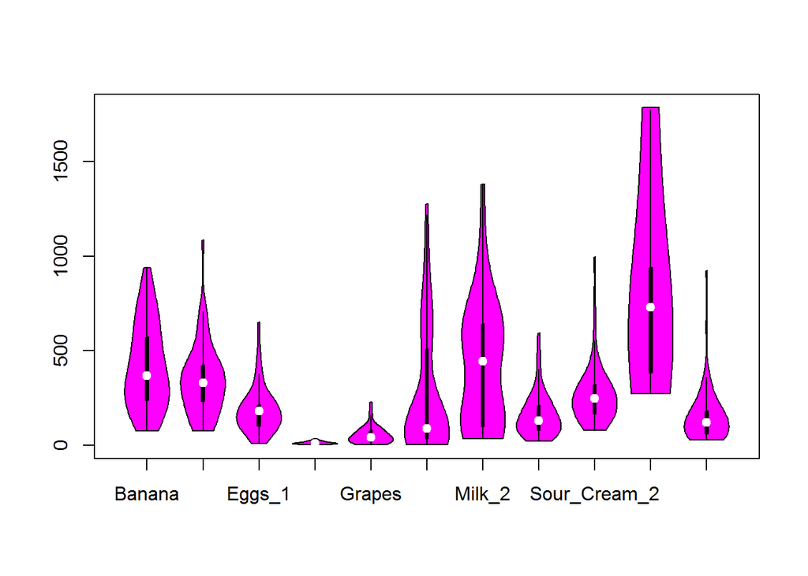

The violin plot of the product dates with sales is given below:

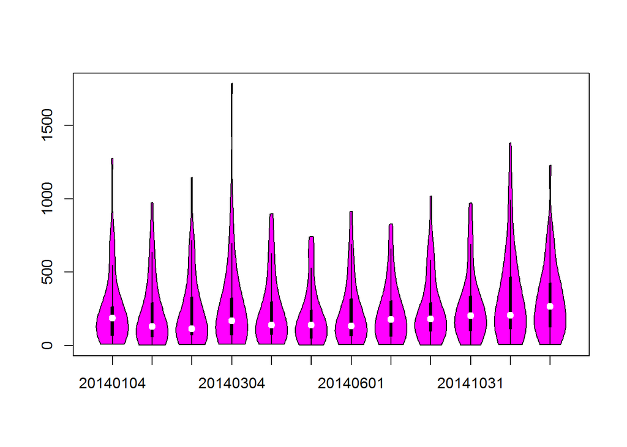

From analysis of the violin plots for the products, Vastlakukkel has the highest median and mean values. Also, it has heavy sales towards the lower half

## Exercise 6

### Draw Q-Q plot for whole data from task 1

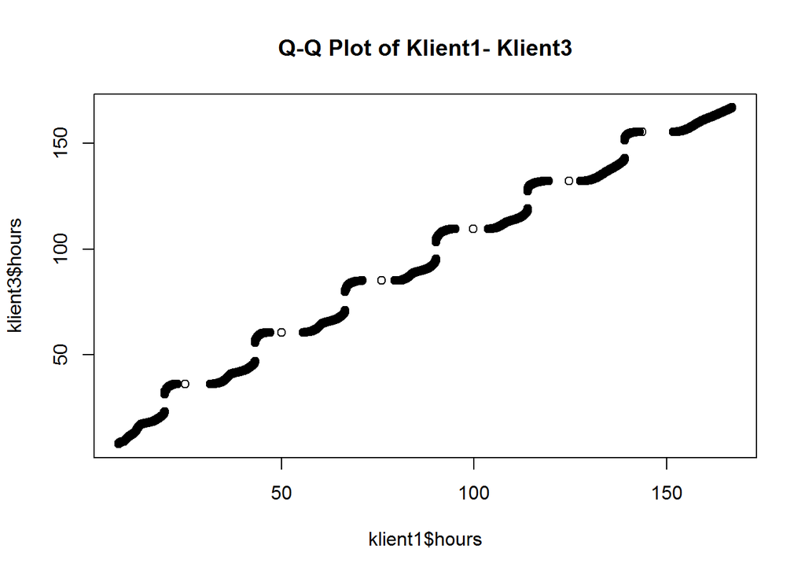

```r
qqplot(klient1$hours, klient3$hours, main = "Q-Q Plot of Klient1- Klient3")
```

The Q-Q plot shows a normal distribution. However the points are greatly disjointed together